# Rapport - Projet Final

### Questionnements sur le jeu de données

A partir de ce jeu de données, plusieurs questions peuvent être soulevées. Tous d’abord le jeu de données ne concerne un échantillon de sujets restreint : on se concentre sur des enfants. Il pourraît être pertinant de reconduire l’expérience sur un public plus âgé, voir adulte, car on peut se demander si les sujets atteints de troubles autistiques développent des stratégies les aidant à comprendre les présuppositions ou alors si justement leur compréhension reste limitée, même en grandissant.

Le deuxième point qui peut être souligné c’est concernant la forme des stimulis. En effet, un stimuli prend la forme suivante : une phrase suivie d’une présupposition à partir de cette phrase. L’enfant doit ensuite évaluer si la présupposition est juste ou pas. On a donc une expérience basée sur des jugements de justesse, et ça nous amène à évaluer juste la capacité de compréhension des sujets, et pas les capacités performatives : on ne peut pas savoir si les sujets peuvent faire eux-même des présuppositions.

On peut également se questionner sur la pertinence des variables *VMA* et *Raven* qui sont respectivements des tests de compétence orale et d’intelligence non-verbale et logiques. Concernant le score *Raven*, regardons ci-dessous le graphique montrant le lien entre réussite et score *Raven*.

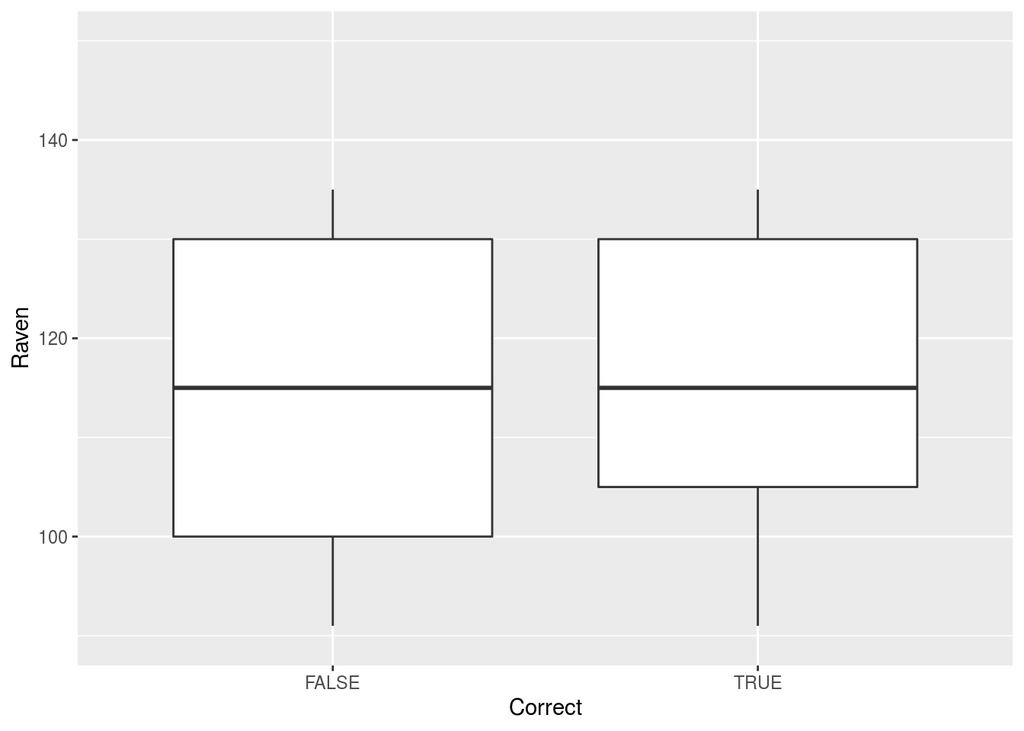

```r
data3 <- ggplot(data2, aes(x=Correct, y=Raven))+ geom_boxplot()
data3 + ylim(90, 150)
```

On observe que les médianes sont à peu près au même niveau. Il semblerait que les sujets ayant un score *Raven* bas ont plus de chance de ne pas réussir l’expérience, cependant les différences restent minimales donc on peut remettre en doute cette affirmation.